# Part I - (Dataset Exploration For The Ford GoBike Trip Data)

## Introduction

In this Analysis, we will explore the Ford GoBike Dataset. Which is a set of records documenting individual rides in a bike sharing system covering the San Francisco Bay area. during the analysis process, we will explore the distribution of several variables, the relation between certain parameters and the effect of multiple variables has on each other.

## Preliminary Wrangling

```python
# import all packages and set plots to be embedded inline
import numpy as np
import pandas as pd
import matplotlib.pyplot as plt
import seaborn as sns
import math
import calendar
```

```python
# loading in the dataset into a pandas dataframe
df = pd.read_csv('data/raw/201902-fordgobike-tripdata_raw.csv')
```

```python
# checking the shape of the data
df.shape
```

```
(183412, 16)
```

```python
# printing data sample for visual assessment
df.head(10)
```

|  | duration_sec | start_time | end_time | start_station_id | start_station_name | start_station_latitude | start_station_longitude | end_station_id | end_station_name | end_station_latitude | end_station_longitude | bike_id | user_type | member_birth_year | member_gender | bike_share_for_all_trip |
| --- | --- | --- | --- | --- | --- | --- | --- | --- | --- | --- | --- | --- | --- | --- | --- | --- |
| 0 | 52185 | 2019-02-28 17:32:10.1450 | 2019-03-01 08:01:55.9750 | 21.0 | Montgomery St BART Station (Market St at 2nd St) | 37.789625 | -122.400811 | 13.0 | Commercial St at Montgomery St | 37.794231 | -122.402923 | 4902 | Customer | 1984.0 | Male | No |
| 1 | 42521 | 2019-02-28 18:53:21.7890 | 2019-03-01 06:42:03.0560 | 23.0 | The Embarcadero at Steuart St | 37.791464 | -122.391034 | 81.0 | Berry St at 4th St | 37.775880 | -122.393170 | 2535 | Customer | NaN | NaN | No |
| 2 | 61854 | 2019-02-28 12:13:13.2180 | 2019-03-01 05:24:08.1460 | 86.0 | Market St at Dolores St | 37.769305 | -122.426826 | 3.0 | Powell St BART Station (Market St at 4th St) | 37.786375 | -122.404904 | 5905 | Customer | 1972.0 | Male | No |
| 3 | 36490 | 2019-02-28 17:54:26.0100 | 2019-03-01 04:02:36.8420 | 375.0 | Grove St at Masonic Ave | 37.774836 | -122.446546 | 70.0 | Central Ave at Fell St | 37.773311 | -122.444293 | 6638 | Subscriber | 1989.0 | Other | No |
| 4 | 1585 | 2019-02-28 23:54:18.5490 | 2019-03-01 00:20:44.0740 | 7.0 | Frank H Ogawa Plaza | 37.804562 | -122.271738 | 222.0 | 10th Ave at E 15th St | 37.792714 | -122.248780 | 4898 | Subscriber | 1974.0 | Male | Yes |
| 5 | 1793 | 2019-02-28 23:49:58.6320 | 2019-03-01 00:19:51.7600 | 93.0 | 4th St at Mission Bay Blvd S | 37.770407 | -122.391198 | 323.0 | Broadway at Kearny | 37.798014 | -122.405950 | 5200 | Subscriber | 1959.0 | Male | No |
| 6 | 1147 | 2019-02-28 23:55:35.1040 | 2019-03-01 00:14:42.5880 | 300.0 | Palm St at Willow St | 37.317298 | -121.884995 | 312.0 | San Jose Diridon Station | 37.329732 | -121.901782 | 3803 | Subscriber | 1983.0 | Female | No |
| 7 | 1615 | 2019-02-28 23:41:06.7660 | 2019-03-01 00:08:02.7560 | 10.0 | Washington St at Kearny St | 37.795393 | -122.404770 | 127.0 | Valencia St at 21st St | 37.756708 | -122.421025 | 6329 | Subscriber | 1989.0 | Male | No |
| 8 | 1570 | 2019-02-28 23:41:48.7900 | 2019-03-01 00:07:59.7150 | 10.0 | Washington St at Kearny St | 37.795393 | -122.404770 | 127.0 | Valencia St at 21st St | 37.756708 | -122.421025 | 6548 | Subscriber | 1988.0 | Other | No |
| 9 | 1049 | 2019-02-28 23:49:47.6990 | 2019-03-01 00:07:17.0250 | 19.0 | Post St at Kearny St | 37.788975 | -122.403452 | 121.0 | Mission Playground | 37.759210 | -122.421339 | 6488 | Subscriber | 1992.0 | Male | No |

### The structure of the dataset.

The dataset consist of 183412 records containing 16 columns. the columns and their description info are in the table below

| Column | Description |
| --- | --- |
| duration_sec | the duration of the trip in seconds |
| start_time | the start time of the trip |
| end_time | The end time of the trip |
| start_station_id | the start station's ID |
| start_station_name | the start station's Name |
| start_station_latitude | the start station's Latitude |
| start_station_longitude | the start station's Longitude |
| end_station_id | the end station's ID |
| end_station_name | the end station's Name |
| end_station_latitude | the end station's Latitude |
| end_station_longitude | the end station's Longitude |
| bike_id | the bike's ID |
| user_type | the Type of user (Subscriber/Customer) |
| member_birth_year | the member's Birth year |
| member_gender | the member's Gender |
| bike_share_for_all_trip | Whether the bike was shared for all trips |

### The main features of interest in the dataset.

the main features of interest in this are duration_sec and bike_share_for_all_trip. we will focus on analyzing them and their relation ships with other variables.

### What features in the dataset do you think will help support your investigation into your feature(s) of interest?

the variables that are most likely to support the investigation are: member_birth_year, distance (will be calculated using longitude and latitude), user_type and member_gender.

### Data Cleaning

Before we can start exploring the Dataset, we need to clean the Data to make sure it's clean and Tidy

```python
# creating a copy of the dataframe to work on inorder to keep the original data
df_clean = df.copy()
```

#### Completeness

the first step is to check the data set for null values

```python
# checking for missing values
df_clean.info()
```

```
<class 'pandas.core.frame.DataFrame'>
RangeIndex: 183412 entries, 0 to 183411
Data columns (total 16 columns):
 #   Column                   Non-Null Count   Dtype
---  ------                   --------------   -----
 0   duration_sec             183412 non-null  int64
 1   start_time               183412 non-null  object
 2   end_time                 183412 non-null  object
 3   start_station_id         183215 non-null  float64
 4   start_station_name       183215 non-null  object
 5   start_station_latitude   183412 non-null  float64
 6   start_station_longitude  183412 non-null  float64
 7   end_station_id           183215 non-null  float64
 8   end_station_name         183215 non-null  object
 9   end_station_latitude     183412 non-null  float64
 10  end_station_longitude    183412 non-null  float64
 11  bike_id                  183412 non-null  int64
 12  user_type                183412 non-null  object
 13  member_birth_year        175147 non-null  float64
 14  member_gender            175147 non-null  object
 15  bike_share_for_all_trip  183412 non-null  object
dtypes: float64(7), int64(2), object(7)
memory usage: 22.4+ MB
```

```python
#checking number of null values in each column
df_clean.isnull().sum()
```

```
duration_sec                  0
start_time                    0
end_time                      0
start_station_id            197
start_station_name          197
start_station_latitude        0
start_station_longitude       0
end_station_id              197
end_station_name            197
end_station_latitude          0
end_station_longitude         0
bike_id                       0
user_type                     0
member_birth_year          8265
member_gender              8265
bike_share_for_all_trip       0
dtype: int64
```

By looking at the columns info we can see that we have 197 records missing station names and 8265 records missing member info. As their numbers are negligible compared to the dataset size, we can just drop those records.

```python
# dropping null records
df_clean.dropna(inplace=True)
```

```python
#verifying if the null records were dropped
df_clean.isna().sum()
```

```
duration_sec               0
start_time                 0
end_time                   0
start_station_id           0
start_station_name         0
start_station_latitude     0
start_station_longitude    0
end_station_id             0
end_station_name           0
end_station_latitude       0
end_station_longitude      0
bike_id                    0
user_type                  0
member_birth_year          0
member_gender              0
bike_share_for_all_trip    0
dtype: int64
```

#### Duplicates

the next step is to look for duplicates in the dataset

```python
# checking for duplicates
df_clean.duplicated().sum()
```

```
np.int64(0)
```

There are no Duplicates in the dataset

#### Validity

next we need to check the validity of the data

```python
# checking validity of numerical columns
df_clean.describe()
```

|  | duration_sec | start_station_id | start_station_latitude | start_station_longitude | end_station_id | end_station_latitude | end_station_longitude | bike_id | member_birth_year |
| --- | --- | --- | --- | --- | --- | --- | --- | --- | --- |
| count | 174952.000000 | 174952.000000 | 174952.000000 | 174952.000000 | 174952.000000 | 174952.000000 | 174952.000000 | 174952.000000 | 174952.000000 |
| mean | 704.002744 | 139.002126 | 37.771220 | -122.351760 | 136.604486 | 37.771414 | -122.351335 | 4482.587555 | 1984.803135 |
| std | 1642.204905 | 111.648819 | 0.100391 | 0.117732 | 111.335635 | 0.100295 | 0.117294 | 1659.195937 | 10.118731 |
| min | 61.000000 | 3.000000 | 37.317298 | -122.453704 | 3.000000 | 37.317298 | -122.453704 | 11.000000 | 1878.000000 |
| 25% | 323.000000 | 47.000000 | 37.770407 | -122.411901 | 44.000000 | 37.770407 | -122.411647 | 3799.000000 | 1980.000000 |
| 50% | 510.000000 | 104.000000 | 37.780760 | -122.398279 | 101.000000 | 37.781010 | -122.397437 | 4960.000000 | 1987.000000 |
| 75% | 789.000000 | 239.000000 | 37.797320 | -122.283093 | 238.000000 | 37.797673 | -122.286533 | 5505.000000 | 1992.000000 |
| max | 84548.000000 | 398.000000 | 37.880222 | -121.874119 | 398.000000 | 37.880222 | -121.874119 | 6645.000000 | 2001.000000 |

looking at the member birth year we can see that we have members born in 1878, which is most likely an entry issue. so to fix this issue we will remove all data with ages larger than one hundred as they are less likely to be valid. As the data was in 2019 that would make the minimum year 1920.

```python
# removing member birth years less that 1920
df_clean = df_clean[df_clean['member_birth_year'] > 1920]
```

#### Tidiness

we have both start_time and end_time containing the date and time data, which need to be separated.

```python
#seperating the start time column into date and time columns
df_clean['start_time'] = pd.to_datetime(df_clean['start_time'])
df_clean['start_date'] = df_clean['start_time'].dt.date
df_clean['start_time'] = df_clean['start_time'].dt.time
```

```python
#seperating the end time column into date and time columns
df_clean['end_time'] = pd.to_datetime(df_clean['end_time'])
df_clean['end_date'] = df_clean['end_time'].dt.date
df_clean['end_time'] = df_clean['end_time'].dt.time
```

```python
#checking the data visually
df_clean.head(10)
```

|  | duration_sec | start_time | end_time | start_station_id | start_station_name | start_station_latitude | start_station_longitude | end_station_id | end_station_name | end_station_latitude | end_station_longitude | bike_id | user_type | member_birth_year | member_gender | bike_share_for_all_trip | start_date | end_date |
| --- | --- | --- | --- | --- | --- | --- | --- | --- | --- | --- | --- | --- | --- | --- | --- | --- | --- | --- |
| 0 | 52185 | 17:32:10.145000 | 08:01:55.975000 | 21.0 | Montgomery St BART Station (Market St at 2nd St) | 37.789625 | -122.400811 | 13.0 | Commercial St at Montgomery St | 37.794231 | -122.402923 | 4902 | Customer | 1984.0 | Male | No | 2019-02-28 | 2019-03-01 |
| 2 | 61854 | 12:13:13.218000 | 05:24:08.146000 | 86.0 | Market St at Dolores St | 37.769305 | -122.426826 | 3.0 | Powell St BART Station (Market St at 4th St) | 37.786375 | -122.404904 | 5905 | Customer | 1972.0 | Male | No | 2019-02-28 | 2019-03-01 |
| 3 | 36490 | 17:54:26.010000 | 04:02:36.842000 | 375.0 | Grove St at Masonic Ave | 37.774836 | -122.446546 | 70.0 | Central Ave at Fell St | 37.773311 | -122.444293 | 6638 | Subscriber | 1989.0 | Other | No | 2019-02-28 | 2019-03-01 |
| 4 | 1585 | 23:54:18.549000 | 00:20:44.074000 | 7.0 | Frank H Ogawa Plaza | 37.804562 | -122.271738 | 222.0 | 10th Ave at E 15th St | 37.792714 | -122.248780 | 4898 | Subscriber | 1974.0 | Male | Yes | 2019-02-28 | 2019-03-01 |
| 5 | 1793 | 23:49:58.632000 | 00:19:51.760000 | 93.0 | 4th St at Mission Bay Blvd S | 37.770407 | -122.391198 | 323.0 | Broadway at Kearny | 37.798014 | -122.405950 | 5200 | Subscriber | 1959.0 | Male | No | 2019-02-28 | 2019-03-01 |
| 6 | 1147 | 23:55:35.104000 | 00:14:42.588000 | 300.0 | Palm St at Willow St | 37.317298 | -121.884995 | 312.0 | San Jose Diridon Station | 37.329732 | -121.901782 | 3803 | Subscriber | 1983.0 | Female | No | 2019-02-28 | 2019-03-01 |
| 7 | 1615 | 23:41:06.766000 | 00:08:02.756000 | 10.0 | Washington St at Kearny St | 37.795393 | -122.404770 | 127.0 | Valencia St at 21st St | 37.756708 | -122.421025 | 6329 | Subscriber | 1989.0 | Male | No | 2019-02-28 | 2019-03-01 |
| 8 | 1570 | 23:41:48.790000 | 00:07:59.715000 | 10.0 | Washington St at Kearny St | 37.795393 | -122.404770 | 127.0 | Valencia St at 21st St | 37.756708 | -122.421025 | 6548 | Subscriber | 1988.0 | Other | No | 2019-02-28 | 2019-03-01 |
| 9 | 1049 | 23:49:47.699000 | 00:07:17.025000 | 19.0 | Post St at Kearny St | 37.788975 | -122.403452 | 121.0 | Mission Playground | 37.759210 | -122.421339 | 6488 | Subscriber | 1992.0 | Male | No | 2019-02-28 | 2019-03-01 |
| 10 | 458 | 23:57:57.211000 | 00:05:35.435000 | 370.0 | Jones St at Post St | 37.787327 | -122.413278 | 43.0 | San Francisco Public Library (Grove St at Hyde... | 37.778768 | -122.415929 | 5318 | Subscriber | 1996.0 | Female | Yes | 2019-02-28 | 2019-03-01 |

In the above code we separated the columns into start_date and end_date containing the date data, and start_time, end_time containing the time data

#### Columns Data Types

in the final cleaning phase we need to make sure every column has the correct data type

```python
#checking the data types of the columns
df_clean.dtypes
```

```
duration_sec                 int64
start_time                  object
end_time                    object
start_station_id           float64
start_station_name          object
start_station_latitude     float64
start_station_longitude    float64
end_station_id             float64
end_station_name            object
end_station_latitude       float64
end_station_longitude      float64
bike_id                      int64
user_type                   object
member_birth_year          float64
member_gender               object
bike_share_for_all_trip     object
start_date                  object
end_date                    object
dtype: object
```

In order to fix the data types we need to fix the following:

- (start_station/end_station)_id: to int
- user_type: to category
- member_birth_year: to int
- member_gender: to category
- bike_share_for_all_trip: to category

```python
#fixing the data types of the columns
df_clean['start_station_id'] = df_clean['start_station_id'].astype(int)
df_clean['end_station_id'] = df_clean['end_station_id'].astype(int)
df_clean['bike_id'] = df_clean['bike_id'].astype(int)
df_clean['member_birth_year'] = df_clean['member_birth_year'].astype(int)
df_clean['user_type'] = df_clean['user_type'].astype('category')
df_clean['member_gender'] = df_clean['member_gender'].astype('category')
df_clean['bike_share_for_all_trip'] = df_clean['bike_share_for_all_trip'].astype('category')
```

```python
df_clean.dtypes
```

```
duration_sec                  int64
start_time                   object
end_time                     object
start_station_id              int64
start_station_name           object
start_station_latitude      float64
start_station_longitude     float64
end_station_id                int64
end_station_name             object
end_station_latitude        float64
end_station_longitude       float64
bike_id                       int64
user_type                  category
member_birth_year             int64
member_gender              category
bike_share_for_all_trip    category
start_date                   object
end_date                     object
dtype: object
```

with the data types fixed the data is cleaned.

#### Creating the additional parameters

##### distance

one of the variables we could compute is the distant traveled in Trip. this can be calculated using the longitude and latitude through the haversine formula. the formula and its code has been referenced from https://www.movable-type.co.uk/scripts/latlong.html. Please view the page to learn more

```python
# calculating the distance between the start and end stations using the haversine formula. this returns the distance in miters
def calc_distance(lat1, lon1, lat2, lon2):
    R = 6371e3  #meters
    phi1 = math.radians(lat1)
    phi2 = math.radians(lat2)
    delta_phi = math.radians(lat2 - lat1)
    delta_lambda = math.radians(lon2 - lon1)
    a = math.sin(delta_phi / 2)**2 + math.cos(phi1) * math.cos(phi2) * math.sin(delta_lambda / 2)**2
    a = 2 * math.atan2(math.sqrt(a), math.sqrt(1 - a))
    return R * a
```

```python
#creating the distance column
df_clean['distance'] = df_clean.apply(lambda x: calc_distance(x['start_station_latitude'], x['start_station_longitude'], x['end_station_latitude'], x['end_station_longitude']), axis=1)
df_clean['distance'] = df_clean['distance'].astype(int)
df_clean['distance'].head(10)
```

```
0      544
2     2704
3      260
4     2409
5     3332
6     2028
7     4532
8     4532
9     3664
10     979
Name: distance, dtype: int64
```

```python
#description statistics of the distance column
df_clean['distance'].describe()
```

```
count    174877.000000
mean       1689.399172
std        1096.668979
min           0.000000
25%         910.000000
50%        1429.000000
75%        2223.000000
max       69469.000000
Name: distance, dtype: float64
```

with this we created a distance variable that contains the traveled distance in meters

##### Age

to create the age we will subtract the birth year from 2019 as it was the year the trips

```python
# creating the age column
df_clean['age'] = 2019 - df_clean['member_birth_year']
```

##### day of week

to create a day of week parameter we will take the day of week from the start date

```python
#getting the day of week
df_clean['start_day'] = df_clean['start_date'].apply(lambda x: calendar.day_name[x.weekday()])
```

```python
#creating a category type for the day of the week for sorting
days = ['Monday', 'Tuesday', 'Wednesday', 'Thursday', 'Friday', 'Saturday', 'Sunday']
day_type = pd.CategoricalDtype(categories=days, ordered=True)
df_clean['start_day'] = df_clean['start_day'].astype(day_type)
```

#### finally we need to reset the index, then saving the data into clean data file

```python
#resetting the index
df_clean.reset_index(drop=True, inplace=True)
```

```python
#saving the cleaned data to a new csv file
df_clean.to_csv('data/clean/201902-fordgobike-tripdata_clean.csv', index=False)
```

## Univariate Exploration

In this section, we will investigate distributions of individual variables.

### Taking a Random Sample

as the data is too large for plotting we will need to take a sample of the data to plot with

```python
# taking a random sample of the data to work with
random_seed = 42
df_clean_sample = df_clean.sample(1000, random_state=random_seed)
```

### what is the distribution of duration and what is the most common duration of rental ?

to look at the distribution we will need first to look at the descriptive statistics of the duration_sec column

```python
df_clean_sample['duration_sec'].describe()
```

```
count     1000.000000
mean       726.954000
std       2168.917953
min         70.000000
25%        306.750000
50%        496.000000
75%        767.500000
max      60441.000000
Name: duration_sec, dtype: float64
```

As the data contains some valid outliers with large values, we will need to convert the data into minutes in order to look at the data better

```python
def duration_hist(data, bins_step, ticks_step, x_label, y_label, title, rotation):
    plt.figure(figsize=(10, 5));
    bins = np.arange(0, data.max() + bins_step, bins_step)
    plt.hist(data, bins=bins)
    plt.xlabel(x_label)
    plt.ylabel(y_label)
    plt.title(title)
    plt.xticks(np.arange(0, data.max() + ticks_step, ticks_step), rotation=rotation)
```

```python
#converting the duration column to minutes
duration_min = df_clean_sample['duration_sec'] / 60
```

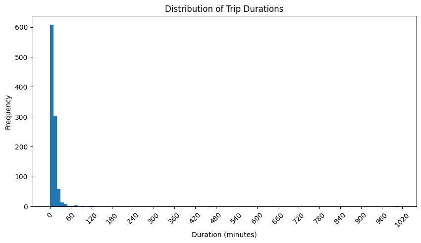

```python
#plotting the distribution of the duration in minutes
#setting the xticks to be in 60 minutes intervals
duration_hist(duration_min, 10, 60, 'Duration (minutes)', 'Frequency', 'Distribution of Trip Durations', 45)
```

```python
#confirming the count of trips with duration greater than 60 minutes in the whole dataset
df_clean[df_clean['duration_sec'] > 3600].shape[0]
```

```
1386
```

```python
# confirming the count of trips with duration greater than 60 minutes in the sample dataset
df_clean_sample[df_clean_sample['duration_sec'] > 3600].shape[0]
```

```
10
```

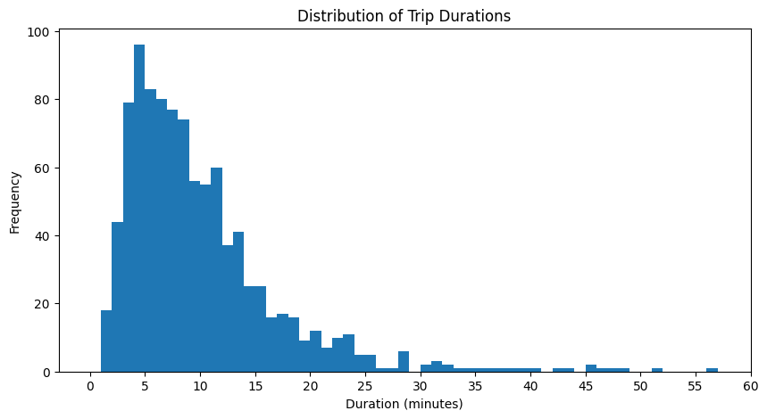

```python
duration_hist(duration_min[duration_min <= 60], 1, 5, 'Duration (minutes)', 'Frequency', 'Distribution of Trip Durations', 0)
```

### What is the ratio of the bike share for all trip ?

in order to look at the look at the ration of the all trip bike shares, we will plot a bar plot of the variable

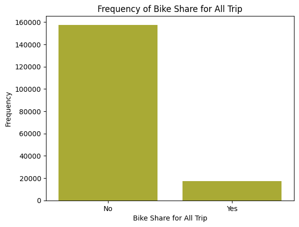

```python
sns.countplot(data=df_clean, x='bike_share_for_all_trip', color='tab:olive')
plt.xlabel('Bike Share for All Trip')
plt.ylabel('Frequency')
plt.title('Frequency of Bike Share for All Trip');
```

#### conclusion

The bar plot above shows that the majority of bike trips are not shared for all trips. with a small minority sharing for all trip

### What is the distribution of the age of members ?

To look at the distribution of age we will create a histogram for it.

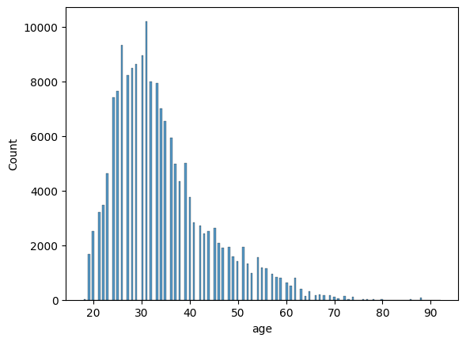

```python
#plotting the histogram of the age column
sns.histplot(data=df_clean, x='age', color='tab:blue')
```

### What days is the rental used most ?

In order to answer this question we will need to plot a bar chart for the days of week.

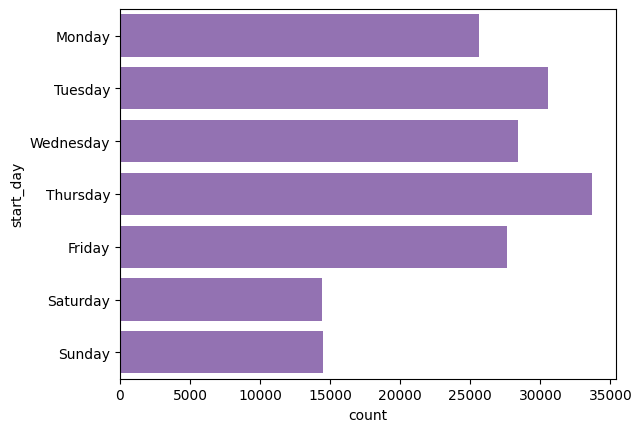

```python
#plotting a horizontal bar chart of the day of the week
sns.countplot(data=df_clean, y='start_day', color='tab:purple')
```

#### Conclusion:

From the plot above, We can determine that of the days of the week Thursday has the most traffic, followed by Tuesday. With Saturday and Sunday Having the least traffic by a good margin.

### Of the features you investigated, were there any unusual distributions? Did you perform any operations on the data to tidy, adjust, or change the form of the data? If so, why did you do this?

there were no unusual distributions as the duration and age are logically expected to be this way. and I needed to change the duration data to minutes for the histogram to be readable.

## Bivariate Exploration

### Are the Trips facing delays ?

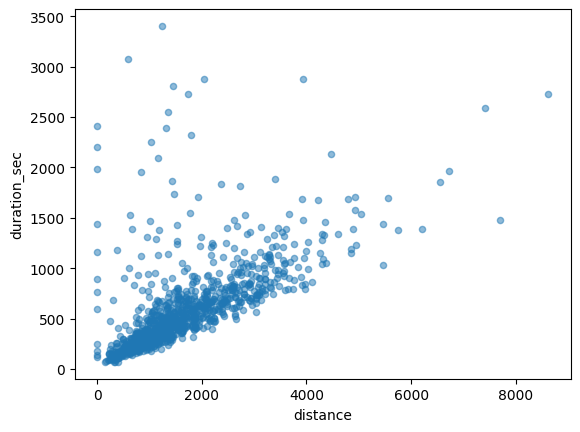

```python
df_clean_sample[df_clean_sample["duration_sec"] <= 3600].plot(kind="scatter", x='distance', y='duration_sec', alpha=0.5)
```

#### Conclusion:

As seen above the relation is mostly a high correlation, with some Trips most likely facing some delay and multiple trips that have a high duration time with no distance traveled which indicates roundabout trips returning to the starting point in the end of the trip.

### Is there a difference of time between sharing for all trip and not?

For this Question, we will plot a box plot between bike_share_for_all_trip and duration_sec variables to see if the distribution differs between them. We will filter the outliers from the duration_sec for the plot to be readable.

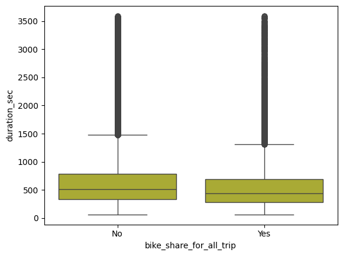

```python
sns.boxplot(data=df_clean[df_clean['duration_sec'] < 3600], x="bike_share_for_all_trip", y="duration_sec", color='tab:olive')
```

#### Conclusion:

We can see that the duration is slightly less in average for the members sharing all trip.

### Are different member types more likely to share all trip ?

In order to answer this question we will plot a heat map between the user_type and bike_share_for_all_trip variables

Before we can plot we need to prepare the data

```python
#preparing the data for the heatmap
df_heatmap = df_clean.groupby(['user_type', 'bike_share_for_all_trip'], observed=False).size().reset_index(name='count')
df_heatmap = df_heatmap.pivot(index='user_type', columns='bike_share_for_all_trip', values='count')
```

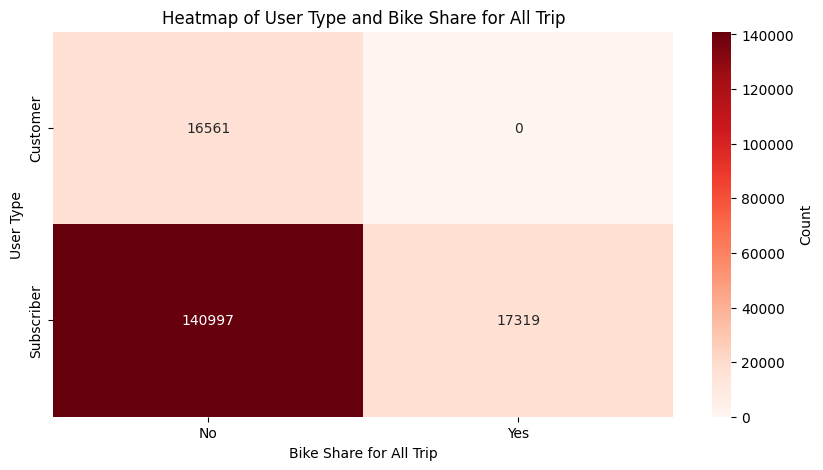

```python
#plotting the heatmap

plt.figure(figsize=(10, 5))
sns.heatmap(df_heatmap, annot=True, fmt='d', cmap='Reds', cbar_kws={'label': 'Count'})
plt.xlabel('Bike Share for All Trip')
plt.ylabel('User Type')
plt.title('Heatmap of User Type and Bike Share for All Trip');
```

#### Conclusion:

From the heatmap above, We can see that no customers share all trip, with a small percentage of Subscribers do share all trip.

### Talk about some of the relationships you observed in this part of the investigation. How did the feature(s) of interest vary with other features in the dataset?

In the Bivariate analysis above we explored three relationships. First, through the scatter plot we observed a positive correlation relation between duration and distance with a small number of trip facing delays and some roundabout trips. Moreover, in the Box plot we observed a slight difference in duration between all trip bike sharing with member sharing all trip having a slightly lower averages. Finally through the heat map we found that bike sharing for all trip being exclusive to Subscribers only.

### Did you observe any interesting relationships between the other features (not the main feature(s) of interest)?

NO

## Multivariate Exploration

### does duration vary between age and gender ?

For this question we will plot a gender focused FacetGrid with scatter plots between age and duration. we will filter out duration outliers for better observation.

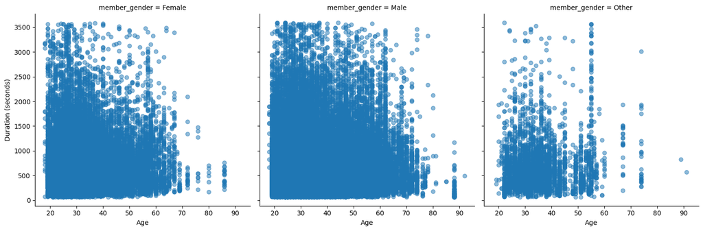

```python
#plotting the facet grid
df_duration = df_clean[df_clean['duration_sec'] <= 3600]
g = sns.FacetGrid(data=df_duration, col='member_gender', col_wrap=3, height=5, aspect=1)
g.map(plt.scatter, 'age', 'duration_sec', alpha=0.5)
g.set_xlabels('Age')
g.set_ylabels('Duration (seconds)')
```

#### Conclusion:

As seen the FacetGrid above, age and gender seem to have no effect on duration of the trip taken.

### Are there any interesting relations we missed ?

In order to investigate this we will plot a scatter matrix of the numerical variables to see what other relations we may have missed.

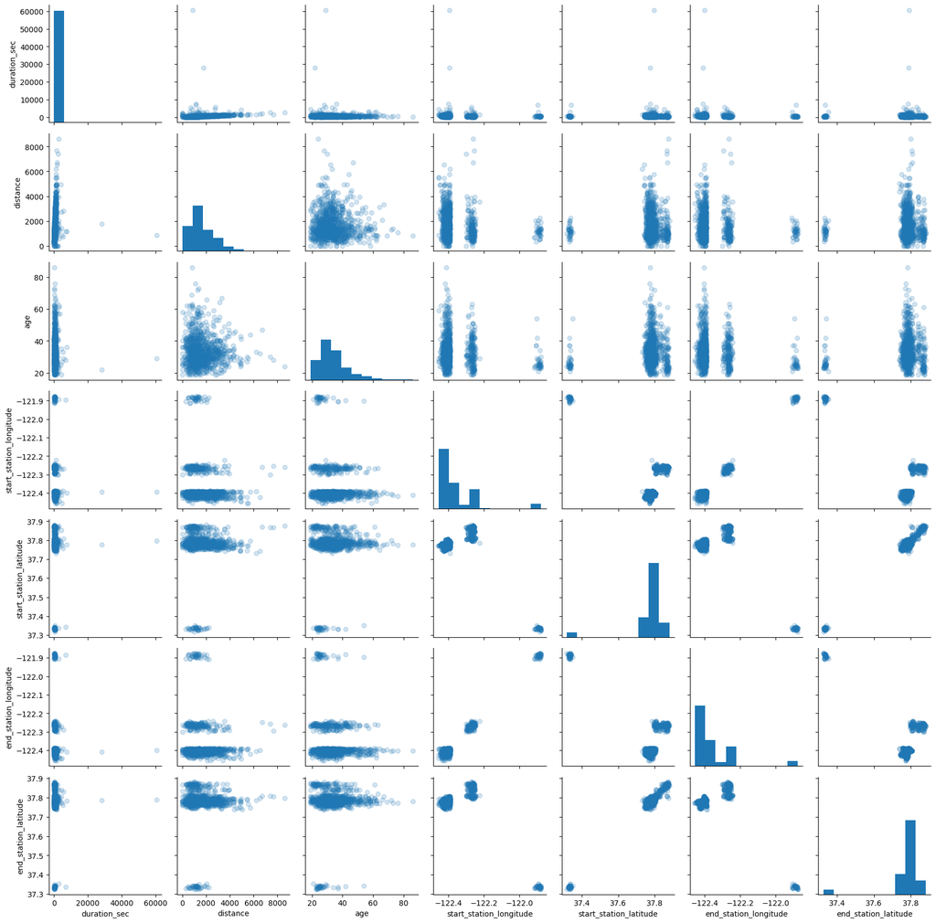

```python
#preparing data for the pair plot
vars = ['duration_sec', 'distance', 'age', 'start_station_longitude', 'start_station_latitude', 'end_station_longitude', 'end_station_latitude']
#plotting the pair plot
g = sns.PairGrid(data=df_clean_sample, vars=vars)
g = g.map_diag(plt.hist)
g = g.map_offdiag(plt.scatter, alpha=0.2)
```

### Talk about some of the relationships you observed in this part of the investigation. Were there features that strengthened each other in terms of looking at your feature(s) of interest?

In this multivariate analysis, we looked first at the effect of age and gender on the duration, then we looked at a scatter matrix to see if we missed any relations. However, no interesting relations have been observed through the plots.

### Were there any interesting or surprising interactions between features?

No

## Conclusions

Through This analysis, we attempted to answer a main question: How is the rental being used. To that end we Cleaned a prepared the data, then we created several visualizations in an effort to answer this question and related observations. The findings from this investigation are as follows:

- Most trips durations are less than 15 minutes, with trips over 25 minutes being rare.
- A small minority share bike all trip.
- The majority of the users are under 40 years old
- The Weekend see little use compared to work day, with Thursday having most traffic followed by Tuesday.
- The Trips seem to be going mostly smoothly, with a few seeming to be facing unexpected delays. We also have a few roundabout trips returning to the start station.
- most users do not share all trip.
- all the users who share all trip are Subscribers, with no Regular Customers sharing all trip.
- the distribution of duration does not vary with age or gender.